# Lab 09: Linear Model Extentions

GE 509

The objective of this lab is to apply the techniques we have been learning about ways to relax the assumptions of linear models and to gain additional practice with Likelihood and Bayesian models of progressively greater complexity. Specifically, we will start from a **Generalized Linear Models** framework, and then additionally consider techniques for dealing with **‘errors in variables’** and **missing data**.

## Case Study: Seedling Recruitment and Soil Moisture

In this analysis we’ll consider the relationship between soil moisture and seedling densities. The response data (y) in this analysis consists of counts of seedlings in 1m x 1m plots. Soil moisture was measured using Time Domain Reflectometry (TDR), a technique where two metal rods are inserted into the ground and an electrical pulse is sent down one rod and measured on the other. The TDR technique actually measures soil impedance, not soil moisture, but soil moisture can be estimated based on empirical calibrations against gravimetric soil moisture measurements (difference between wet and dry weight of soil cores). TDR has the advantage of being much less labor intensive and non-destructive than gravimetric measurement, which permits repeated measurements of the same plots. The Poisson distribution is a natural choice for modeling the seedling count data because the data is both discrete and lacking a defined upper bound. Since we are interested in the relationship between seedling density and a covariate, soil moisture, we’ll make use of the Generalized Linear Models (GLM) framework for fitting a Poisson regression. As a link function, lets start with the standard choice of a log link.

$$log(\mu) = \beta_0 + \beta_1 TDR$$
$$y \sim Pois(\mu)$$

The data for this analysis are provided to you as a Rdata object that contains the following variables:

```
n – sample size
y – seedling counts (individuals/m2)
TDR – raw output from the TDR unit (arbitrary units) for each seedling plot
TDRc – raw TDR output for the calibration samples
SMc – Volumetric soil moisture measurements for the calibration samples (m3/m3)
SMseq – a sequence of soil moisture values used for prediction
```

```r
library(rjags)
load("data/Lab9.RData")
```

For the first part of this analysis we will use the TDR measurements as our covariate. We will deal with the calibration issue later in the lab.

## Maximum Likelihood Poisson Regression

To begin, we will look at the analysis from a Likelihood perspective. As a reminder from lecture, the Likelihood analysis could be performed two ways in R. The first would be to use the “glm” function

```r
PR1 = glm(y ~ TDR, family=poisson(link="log"))
PR1
```

```
##
## Call:  glm(formula = y ~ TDR, family = poisson(link = "log"))
##
## Coefficients:
## (Intercept)          TDR
##      0.5994       3.2862
##
## Degrees of Freedom: 99 Total (i.e. Null);  98 Residual
## Null Deviance:       673.8
## Residual Deviance: 507.3     AIC: 788.8
```

The second approach would be to define the negative log likelihood function yourself and then use a nonlinear optimization function (e.g. nlm, optim) to find the MLE

```r
ic   <- c(0,0) ## initial guess
LnL  <- function(beta){  ## define likelihood
  -sum(dpois(y,exp(beta[1] + beta[2]*TDR),log=TRUE))
}
test <- LnL(ic) ## verify likelihood function works
PR2  <- nlm(LnL,ic) ## maximize the likelihood
PR2
```

```
## $minimum
## [1] 392.3759
##
## $estimate
## [1] 0.5994118 3.2861821
##
## $gradient
## [1] -1.363105e-04 -6.353448e-05
##
## $code
## [1] 1
##
## $iterations
## [1] 12
```

### Lab Report Task 1

1. Plot seedling densities as a function of TDR
2. Add regression line to the plot Hint 1: use “coef” to extract the regression coefficients from the GLM. Hint 2: don’t forget about the link function when plotting the line
3. Briefly *describe* how you would add model confidence and predictive intervals to these curves
4. What would be an appropriate null model to compare to? What metric would you use to compare the two models?
5. Plot the calibration data of TDR vs. soil moisture. Fit a Normal regression model to the calibration data, add the line to the plot, and report the summary table information for the fit

Below, we’ve used the output from GLM to predict y values for a sequence of x values. This line is plotted on top of the seedling densities, plotted as a function of TDR.

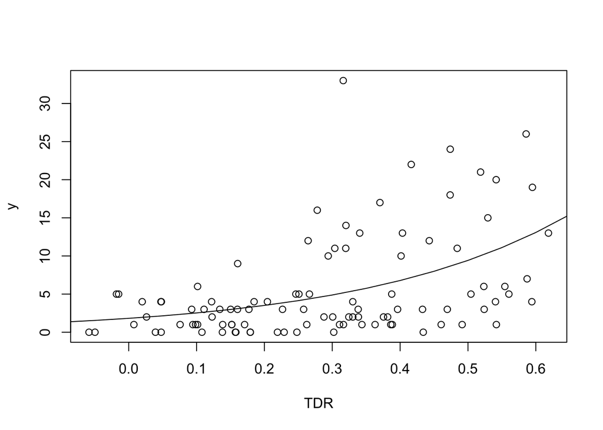

```r
xpred <- seq(-0.1, .7, by = .05)    ## sequence of x values we're going to use for prediction
ypred <- exp(coef(PR1)[1] + coef(PR1)[2]*xpred)
plot(y~TDR); lines(xpred, ypred)
```

To add a model confidence interval, we could carry out a parametric bootstrap, since we have already estimated the parameters using GLM. We could also use the standard error output. A predictive interval, however, would be much more difficult to calculate from the GLM output, because our confidence interval doesn’t distinguish between observation and process error.

The null model would probably be an intercept-only model that does not include TDR as a predictor. We could use AIC to compare the models with and without TDR to see whether TDR has valuable predictive power.

Next, we plot the calibration data that links soil moisture (SM) with TDR, along with a line representing the linear model fitting the two measurement types:

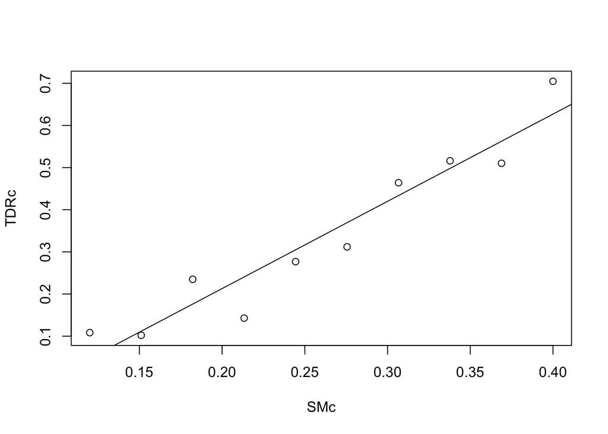

```r
fit <- lm(TDRc ~ SMc)
plot(TDRc ~ SMc)
abline(fit)
```

```r
print(summary(fit))
```

```
##
## Call:
## lm(formula = TDRc ~ SMc)
##
## Residuals:
##       Min        1Q    Median        3Q       Max
## -0.097772 -0.046368  0.004083  0.051629  0.077617
##
## Coefficients:
##             Estimate Std. Error t value Pr(>|t|)
## (Intercept) -0.20107    0.06051  -3.323   0.0105 *
## SMc          2.07048    0.22008   9.408 1.34e-05 ***
## ---
## Signif. codes:  0 '***' 0.001 '**' 0.01 '*' 0.05 '.' 0.1 ' ' 1
##
## Residual standard error: 0.06219 on 8 degrees of freedom
## Multiple R-squared:  0.9171, Adjusted R-squared:  0.9067
## F-statistic: 88.51 on 1 and 8 DF,  p-value: 1.336e-05
```

## Bayesian Poisson Regression

Next we’re going to fit the Poisson regression model from the Bayesian perspective using BUGS. This will allow you to compare the Likelihood and Bayesian approaches and will serve as the foundation for building a more complex model.

To build the Poisson model:

- Start from the ‘univariate_regression’ model from Lab 6
- Drop the prior on *prec* – the Pois has no variance/precision parameter
- Modify the process model to be:

  ```
  log(mu[i]) <- beta[1]+beta[2]*TDR[i]     ## process model
  ```

  Normally JAGS doesn’t let functions be on the left-hand side of an <- but the *log* and *logit* link functions are two important exceptions.
- Modify the data model to be *dpois*

### Lab Report Task 2:

6. Fit the Bayesian Poisson regression model. Provide the DIC, and summary table & posterior density plots for all model parameters. Report the burn in and effective MCMC sample size (You should still be making diagnostic plots but you no longer need to include them).
7. Compare the parameters from the Bayesian fit to the Likelihood fit. Make sure to identify which terms match with which between the models.
8. Plot the model credible interval and predictive interval. Be sure to include the scatterplot of the observed data.
9. How well does the Poisson model match the data? Does 95% of the data fall within the 95% PI?

```r
pois_regression <- "
model{

  beta ~ dmnorm(b0,Vb)      ## prior regression params

  for(i in 1:n){
    log(mu[i]) <- beta[1]+beta[2]*TDR[i]     ## process model
      y[i]  ~ dpois(mu[i])                       ## data model
  }
}
"

# create data object
data <- list(TDR = TDR, y = y, n = n,
             b0 = as.vector(c(0,0)),    ## regression beta means
             Vb = solve(diag(10000,2))) ## regression beta precisions

## initial conditions
inits <- list()
for(i in 1:3){
 inits[[i]] <- list(beta = rnorm(2,0,5))
}

j.model   <- jags.model(file = textConnection(pois_regression),
                             data = data,
                             inits = inits,
                             n.chains = 3)
var.out   <- coda.samples (model = j.model,
                            variable.names = c("beta"),
                                n.iter = 20000)
```

Let’s check that we have convergence and enough samples, after removing 1k of burn in.

```r
jags.burn <- window(var.out,start=1000)  ## remove burn-in
gelman.diag(jags.burn) # very close to 1 - good
```

```
## Potential scale reduction factors:
##
##         Point est. Upper C.I.
## beta[1]          1          1
## beta[2]          1          1
##
## Multivariate psrf
##
## 1
```

```r
effectiveSize(jags.burn) # above 2k - good enough
```

```
##  beta[1]  beta[2]
## 2344.580 2007.674
```

```r
out <- as.matrix(jags.burn)
params <- summary(jags.burn)
dic.pois <- dic.samples(j.model, 5000)

print(dic.pois) # check DIC
```

```
## Mean deviance:  786.7
## penalty 1.936
## Penalized deviance: 788.7
```

```r
print(params)
```

```
##
## Iterations = 1001:21000
## Thinning interval = 1
## Number of chains = 3
## Sample size per chain = 20000
##
## 1. Empirical mean and standard deviation for each variable,
##    plus standard error of the mean:
##
##           Mean     SD  Naive SE Time-series SE
## beta[1] 0.6002 0.1101 0.0004497       0.002594
## beta[2] 3.2806 0.2674 0.0010918       0.006859
##
## 2. Quantiles for each variable:
##
##          2.5%    25%    50%    75%  97.5%
## beta[1] 0.382 0.5266 0.5999 0.6756 0.8102
## beta[2] 2.760 3.0945 3.2834 3.4632 3.8016
```

Now, let’s use the MCMC output to plot the data, along with the model and CI/PI:

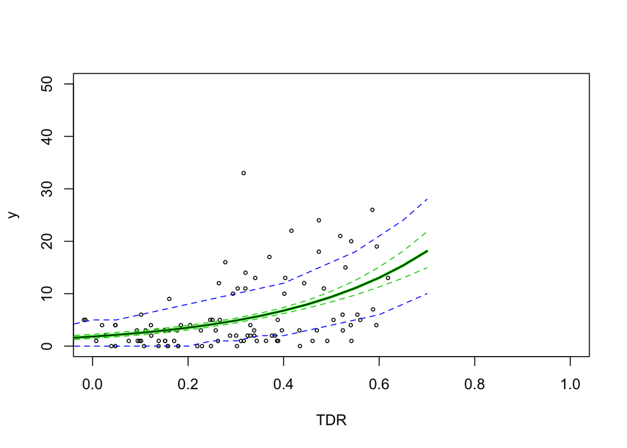

```r
b1 <- params$statistics[1,1]
b2 <- params$statistics[2,1]

## credible and prediction intervals
nsamp <- 5000
samp <- sample.int(nrow(out),nsamp)
npred <- length(xpred)              ##      make predictions for
ypred <- matrix(0.0,nrow=nsamp,ncol=npred)  ## storage for predictive interval
ycred <- matrix(0.0,nrow=nsamp,ncol=npred)  ## storage for credible interval

for(g in seq_len(nsamp)){
  theta = out[samp[g],]
  ycred[g,] <- exp(theta["beta[1]"] + theta["beta[2]"]*xpred)
  ypred[g,] <- rpois(npred,ycred[g,])
}

ci <- apply(ycred,2,quantile,c(0.025,0.5,0.975))  ## credible interval and median
pi <- apply(ypred,2,quantile,c(0.025,0.975))        ## prediction interval
ypred <- exp(mean(b1) + mean(b2)*xpred) ## mean model predictions

plot(TDR,y,cex=0.5,xlim=c(0,1),ylim=c(0,50))
lines(xpred,ci[1,],col=3,lty=2) ## lower CI
lines(xpred,ci[2,],col=3,lwd=3) ## median
lines(xpred,ci[3,],col=3,lty=2) ## upper CI
lines(xpred,pi[1,],col=4,lty=2) ## lower PI
lines(xpred,pi[2,],col=4,lty=2) ## upper PI
lines(xpred, ypred)
```

We see that our predictive interval in blue does not include 95% of our predictions, indicating that we are missing some source of uncertainty.

## Missing Data

It is not uncommon in the real world for a small percentage of data to be missing due to any of a multitude of real-world mistakes. In many cases it is simple enough to ‘drop’ these data, as is the norm in classical analyses. However there are cases where this is undesirable, such as when one has a large number of covariates and you are only missing one and don’t want to drop the whole row, or when individual measurements are very expensive in time or money or are otherwise irreplaceable. From the Bayesian perspective it is possible to formally accommodate missing data by [numerically] integrating over all possible states the data can take on. This technique is sometime referred to as imputing the missing data, or more specifically as multiple imputation because we are proposing many values the data could have been. Doing this (not surprisingly) requires that we specify a prior distribution on the missing data itself. However, the inference will draw on the likelihood, the other covariates, and the response data in order to formally generate the posterior distribution of the missing data. Therefore, it is the posterior that we actually using ‘fill in’ the missing data, not the prior. Finally, it bears mentioning that addressing missing data requires that we meet one very important assumtion – that the data is missing at random. If the process that caused the data to be missing is systematic or in any way related to the process we’re trying to understand then we cannot impute the missing data.

To show how this works:

- Make a copy of your full ‘data’ list and then randomly change one of the TDR values to NA to make it ‘missing’. Make sure to record the value before removing it.
- Make a copy of your JAGS script and add a prior on the missing value. For example, if you removed the 12th TDR measurement you could put a prior on TDR[12] (e.g. a uniform over the range of valid data).
- Re-run the model using this data, but this time add the TDR value you removed to the variables that you track (e.g. TDR[12]) so that we can view the posterior distribution.

```r
pois_regression_missing <- "
model{

  beta ~ dmnorm(b0,Vb)      ## prior regression params
  TDR[8] ~ dunif(0,.6)    ## prior on missing TDR value

  for(i in 1:n){
    log(mu[i]) <- beta[1]+beta[2]*TDR[i]     ## process model
      y[i]  ~ dpois(mu[i])                       ## data model
  }
}
"

TDR.copy <- TDR
TDR.copy[8] <- NA

# create data object
data <- list(TDR = TDR.copy, y = y, n = n,
             b0 = as.vector(c(0,0)),    ## regression beta means
             Vb = solve(diag(10000,2))) ## regression beta precisions

## initial conditions
inits <- list()
for(i in 1:3){
 inits[[i]] <- list(beta = rnorm(2,0,5))
}

j.model   <- jags.model(file = textConnection(pois_regression_missing),
                             data = data,
                             inits = inits,
                             n.chains = 3)
var.out   <- coda.samples (model = j.model,
                            variable.names = c("beta", "TDR[8]"),
                                n.iter = 10000)
params <- summary(var.out)
print(params)
```

```
##
## Iterations = 1001:11000
## Thinning interval = 1
## Number of chains = 3
## Sample size per chain = 10000
##
## 1. Empirical mean and standard deviation for each variable,
##    plus standard error of the mean:
##
##           Mean     SD  Naive SE Time-series SE
## TDR[8]  0.1891 0.1163 0.0006713      0.0009217
## beta[1] 0.6025 0.1084 0.0006259      0.0022620
## beta[2] 3.2786 0.2595 0.0014983      0.0059214
##
## 2. Quantiles for each variable:
##
##            2.5%    25%    50%    75%  97.5%
## TDR[8]  0.01114 0.0955 0.1783 0.2686 0.4379
## beta[1] 0.38662 0.5301 0.6047 0.6748 0.8145
## beta[2] 2.77020 3.1050 3.2737 3.4503 3.7842
```

### Lab Report Task 3:

10. Report the posterior distributions of the missing TDR data. How does this compare to the prior your specified and to the true value?

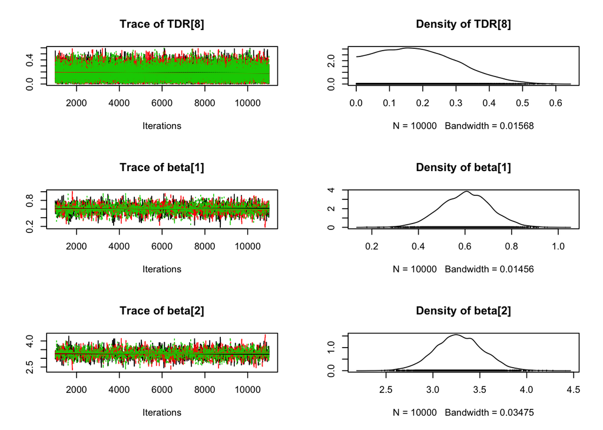

```r
# view density plots for beta and missing TDR value
plot(var.out)
```

```r
TDR[8]
```

```
## [1] 0.3382101
```

Our posterior density is relatively wide, with a mean of .19. Our prior was a uniform distribution from 0 to .6, but the estimated TDR value was likely influenced by the other x and y values in the dataset. The real value is .338, which is within the range of our posterior, but without a high probability.

### Poisson Regression with Errors in Variables

Note: the first two models presented below are for explanation and you don’t have to run them

One obvious problem with the analyses conducted so far is that the covariate has been our proxy data, TDR, which has arbitrary units and is not biologically interesting – there are no noteworthy theories in biology about the effect of soil impedance on plants. What we are really interested in is the impact of soil moisture on our plants, but we never observe soil moisture directly – it is a latent variable. However, we do have a calibration curve that can be used to relate TDR to soil moisture. By far the most common approach in the literature to calibration problems such as this one is to use just only the deterministic process model for the relationship between the two variables in order to transform one variable to another. However, the relationship is not perfect and therefore there is uncertainty in the soil moisture estimates. A full treatment of uncertainty would account for the fact that there is both parameter uncertainty in the calibration curve and residual error in the data model – in other words we want to know the posterior predictive distribution of each soil moisture estimate given the observed TDR measurement. If we knew this we could then use these posterior distributions as informative priors on our data model for the Errors in Variables model we talked about in lecture. If we wanted to fit the calibration curve in JAGS it would just be the simple linear regression model we’ve seen a number of times already

```
model {
  for(i in 1:2) { alpha[i] ~ dnorm(0,0.001)}        ## priors
  sigma ~ dgamma(0.01,0.01)
  for(i in 1:10){
            ESMc[i] <- alpha[1]+alpha[2]*TDRc[i]    ## process model: Expected SMc
            SMc[i] ~ dnorm(ESMc[i],sigma)           ## data model: Soil Moisture calibration
   }
}
```

The Poisson regression model would then be modified based on the errors in variable approach to account for the uncertainty in soil moisture due to the fact that TDR is an imperfect proxy.

```
model {
  alpha ~ dmnorm(abar,aprec)}                            ## informative prior, calibration process
  sigma ~ dgamma(s1,s2)                                  ## informative prior, calibration precision
  for(i in 1:2) { beta[i] ~ dnorm(0,0.001)}              ## Poisson regression priors
  for(i in 1:n){
    ESM[i] <-  alpha[1] + alpha[2]*TDR[i]                ## Errors in variables - process model
    SM[i] ~ dnorm(ESM[i],sigma)                          ## Errors in variables - data model
    log(mu[i]) <- beta[1]+beta[2]*SM[i]                  ## Poisson regression - process model
    y[i] ~ dpois(mu[i])                                      ## Poisson Regression – data model
  }
}
```

Writing the combined model (below) involves little more than putting the code for each of these two models into one file

```r
PoisRegPlusCalib = "
model {
  ### TDR calibration curve
  for(i in 1:2) { alpha[i] ~ dlnorm(0,0.1)}   ## calibration priors
  sigma ~ dgamma(0.1,0.1)
  for(i in 1:10){
    ESMc[i] <- alpha[1] + alpha[2]*TDRc[i]   ## expected soil moisture, calibration process model
    SMc[i] ~ dnorm(ESMc[i],sigma)            ## calibration data model
  }

  ## Seedling Density vs Soil Moisture
  for(i in 1:2) { beta[i] ~ dlnorm(0,0.1)}   ## Poisson regression priors
  for(i in 1:n){
    ESM[i] <-  alpha[1] + alpha[2]*TDR[i]     ## Errors in Variables – process model
    SM[i] ~ dnorm(ESM[i],sigma)               ## Errors in Variables – data model
    log(mu[i]) <- beta[1]+beta[2]*SM[i]       ## Poisson Regression – process model
    y[i] ~ dpois(mu[i])                       ## Poisson Regression – data model
  }
}
"
```

While this model looks larger and more complicated that most we’ve looked at in JAGS, it really just consists of a number of simple parts we’ve seen before. The first part is the fitting of the calibration curve. The second part involves using the calibration curve to estimate soil moisture and then fitting the Poisson regression of seedling density vs soil moisture. Unlike the conventional approach of performing each step sequentially, this approach propagates the error in each step into the final model. Reminder: you may want to specify initial conditions on the model parameters. It is perfectly valid to use the previous estimates (e.g. Task 1) for the initial conditions. For example, if I wanted to initialize alpha to all 0’s and sigma to 5 I would specify list(alpha=c(0,0),sigma(5))

### Lab Report Task 4:

11. Fit the final combined calibration/Poisson regression model and provide a summary table and posterior density plots for the model parameters. Also report the burn in and the effective MCMC sample size.
12. Plot the model credible interval and predictive interval. Extra Credit: Include the scatterplot of the data on the plot, using the posterior CIs for all the latent *SM* variables as the x.
13. How does this fit compare to the previous Poisson regression of seedlings vs TDR in terms of the overall uncertainty in the model (width of credible and predictive intervals)? In qualitative terms, to what degree does ignoring the uncertainty in the TDR/Soil Moisture relationship affect the uncertainty in our parameter estimates and our confidence in our model?

```r
# create data object
data <- list(TDR = TDR, y = y, n = n,
             TDRc = TDRc, SMc = SMc)

## initial conditions
inits <- list()
for(i in 1:3){
 inits[[i]] <- list(beta = rnorm(2,0,5), alpha = rnorm(2,0,5))
}

f1 = lm(SMc ~ TDRc)
alpha = coef(f1)
inits <- list(alpha=alpha,
              SM=alpha[1] + alpha[2]*TDR,
              sigma=1/(summary(f1)$sigma^2),
              beta = rlnorm(2,0,1))

j.model   <- jags.model(file = textConnection(PoisRegPlusCalib),
                             data = data,
                             inits = inits,
                             n.chains = 3)
var.out   <- coda.samples (model = j.model,
                            variable.names = c("beta", "alpha","sigma"),
                                n.iter = 100000, thin = 5)
jags.burn <- window(var.out,start=10000)  ## remove burn-in
out <- as.matrix(jags.burn)
```

Let’s check the GBR diagnostics and effective sample size before continuing:

```r
gelman.diag(jags.burn) # converged!
```

```
## Potential scale reduction factors:
##
##          Point est. Upper C.I.
## alpha[1]       1.00       1.00
## alpha[2]       1.00       1.00
## beta[1]        1.01       1.01
## beta[2]        1.00       1.01
## sigma          1.00       1.01
##
## Multivariate psrf
##
## 1
```

```r
effectiveSize(jags.burn)
```

```
##   alpha[1]   alpha[2]    beta[1]    beta[2]      sigma
## 14232.8851  1804.1237  6495.8724   950.6609  1428.5152
```

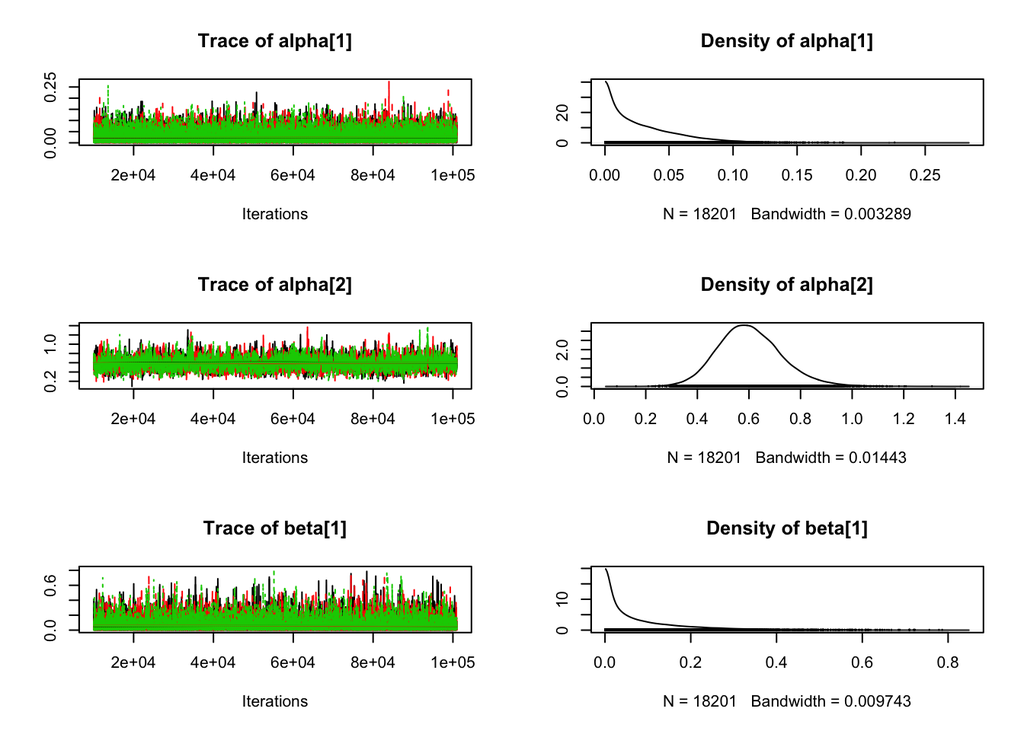

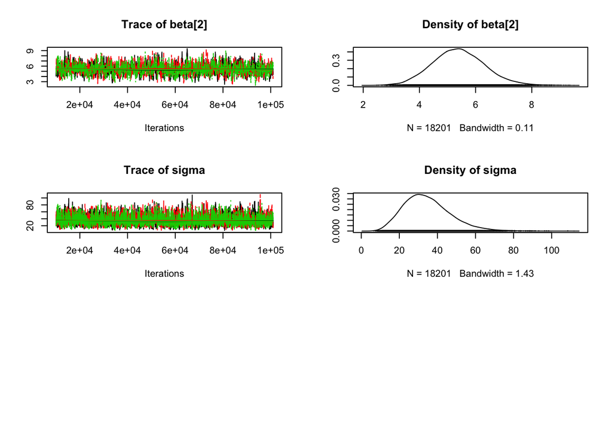

```r
plot(jags.burn)
```

Next, we plot the credible interval and predictive intervals along with the data.

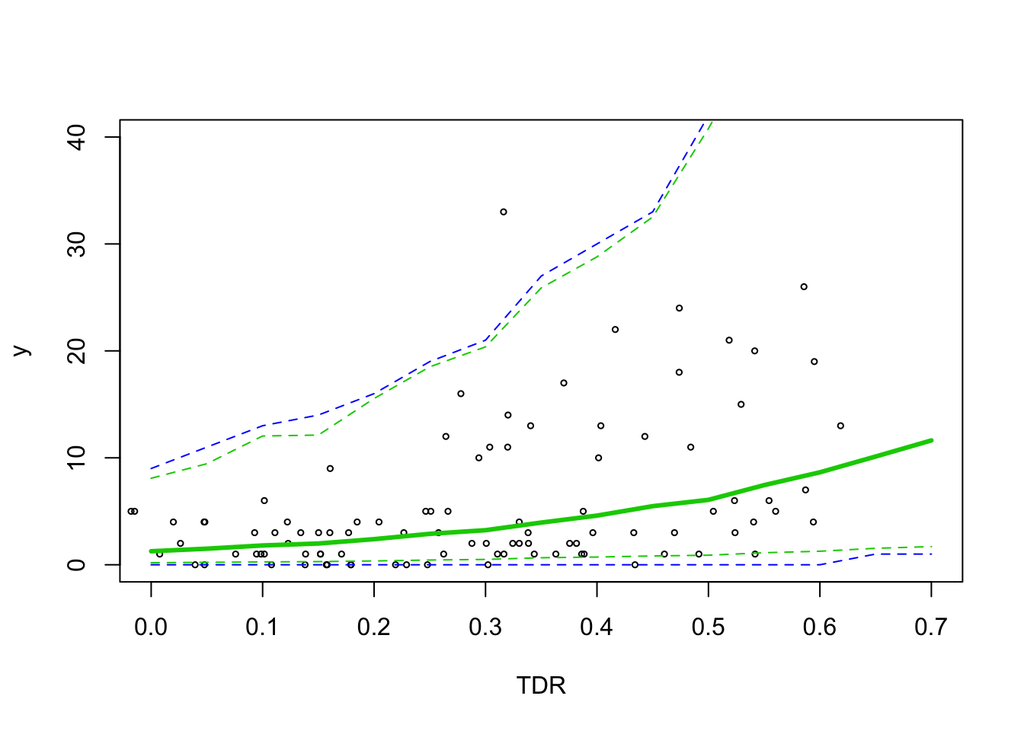

```r
params <- summary(jags.burn)
b1 <- params$statistics[grep("beta[1]", rownames(params$statistics), fixed=TRUE),1]
b2 <- params$statistics[grep("beta[2]", rownames(params$statistics), fixed=TRUE),1]
a1 <- params$statistics[grep("alpha[1]", rownames(params$statistics), fixed=TRUE),1]
a2 <- params$statistics[grep("alpha[2]", rownames(params$statistics), fixed=TRUE),1]
sigma <- params$statistics[grep("sigma", rownames(params$statistics), fixed=TRUE),1]


## credible and prediction intervals
nsamp <- 5000
samp <- sample.int(nrow(out),nsamp)
xpred <- seq(0, .7, by = .05)                   ## sequence of x values we're going to
npred <- length(xpred)                        ##      make predictions for
ypred <- matrix(0.0,nrow=nsamp,ncol=npred)  ## storage for predictive interval
ycred <- matrix(0.0,nrow=nsamp,ncol=npred)  ## storage for credible interval
ESM <- matrix(0.0,nrow=nsamp,ncol=npred)    ## storage for credible interval
SM <- matrix(0.0,nrow=nsamp,ncol=npred) ## storage for credible interval

for(g in seq_len(nsamp)){
  theta = out[samp[g],]
  sd <- sqrt(1/theta["sigma"])
  ESM[g,] <- theta["alpha[1]"] + theta["alpha[2]"]*xpred
  SM[g,] <- rnorm(npred, ESM[g,], sd)
  ycred[g,] <- exp(theta["beta[1]"] + theta["beta[2]"]*SM[g,])
  ypred[g,] <- rpois(npred,ycred[g,])
}

ci <- apply(ycred,2,quantile,c(0.025,0.5,0.975))  ## credible interval and median
pi <- apply(ypred,2,quantile,c(0.025,0.975))        ## prediction interval

plot(TDR,y,cex=0.5,xlim=c(0,.7),ylim=c(0,40))
lines(xpred,ci[1,],col=3,lty=2) ## lower CI
lines(xpred,ci[2,],col=3,lwd=3) ## median
lines(xpred,ci[3,],col=3,lty=2) ## upper CI
lines(xpred,pi[1,],col=4,lty=2) ## lower PI
lines(xpred,pi[2,],col=4,lty=2) ## upper PI
```

Above, we see that this model has much higher uncertainty than the previous model, due to our inclusion of the errors within the X variables. The previous model was overconfident. The mean (solid green line) is similar, so we have a comparable picture of the trends between our soil moisture proxy and seedling densities, but we see that our CI and PI are much broader to contain the majority of the data points. This shows that propagating uncertainty will give us more accurate predictions for where actual observations will fall.